# STAT 467-Recitation 4

## Introduction

During this course, we’ll use R Studio and related tools such as R Markdown etc. However, you should install R Programming to your computer before installing R Studio and its tools.

**Install R and R Studio**

In order to install R, please visit cran.r-project.org. Note that you must firstly install R before installing R Studio as mentioned previously.

After installing R, please visit https://rstudio.com/.

For both softwares, installation processes are same. Download exe file being appropriate for your operating system, then click on **next**, **next**, **next** and **finish.**

In order to find out how to use R and R Studio well, you can visit [my web pages](http://users.metu.edu.tr/ozancan). Besides, you can find out a tutorial for preparing class report via R Markdown from [this page](http://users.metu.edu.tr/ozancan/markdownforclassreports.pdf)

**Installing package and Call it**

R is an open-source software so that you can find a package for almost every procedure from drawing a graph to writing a game. That’s why it is essential to know how to install such packages to our computer and how to use them.

In order to install a package that you haven’t installed yet, you should type `install.packages()` on console and put name of the package in the function.

After installing, to call the loaded library please type `library()` command on your console. For example;

```
install.packages("TSA")
library(TSA)
```

## Basic Matrix Operators

[figure not shown]

### Creating a Matrix in R

Create the following matrices in R.

$$A = \left( \begin{matrix} 2 & 3 & 1 \\ 5 & 3 & 2 \\ 2 & 4 & 10 \end{matrix} \right)$$

and

$$B = \left( \begin{matrix} 2 & 1 & 0 \\ 7 & 6 & 1 \\ 5 & 4 & 8 \end{matrix} \right)$$

```r
A<-matrix(c(2,5,2,3,3,4,1,2,10),nrow = 3)
A
```

```
##      [,1] [,2] [,3]
## [1,]    2    3    1
## [2,]    5    3    2
## [3,]    2    4   10
```

```r
B<-matrix(c(2,7,5,1,6,4,0,1,8),nrow = 3)
B
```

```
##      [,1] [,2] [,3]
## [1,]    2    1    0
## [2,]    7    6    1
## [3,]    5    4    8
```

Extract the first row of the matrix of $A$

```r
A[1,]
```

```
## [1] 2 3 1
```

Extract the third column of the matrix of $B$

```r
B[,3]
```

```
## [1] 0 1 8
```

Extract the entry on the 1st row and 2nd column of the matrix $A$.

```r
A[1,2]
```

```
## [1] 3
```

**Some Special Matrices**

- **Diagonal Matrix**

If you have a vector that contains the elements or the entries of a diagonal matrix, you can create a diagonal matrix with the R command diag. Study the following examples.

```r
a = 1:5
diag(a) # Gives a square matrix with diagonal entries a.
```

```
##      [,1] [,2] [,3] [,4] [,5]
## [1,]    1    0    0    0    0
## [2,]    0    2    0    0    0
## [3,]    0    0    3    0    0
## [4,]    0    0    0    4    0
## [5,]    0    0    0    0    5
```

```r
diag(11:20)
```

```
##       [,1] [,2] [,3] [,4] [,5] [,6] [,7] [,8] [,9] [,10]
##  [1,]   11    0    0    0    0    0    0    0    0     0
##  [2,]    0   12    0    0    0    0    0    0    0     0
##  [3,]    0    0   13    0    0    0    0    0    0     0
##  [4,]    0    0    0   14    0    0    0    0    0     0
##  [5,]    0    0    0    0   15    0    0    0    0     0
##  [6,]    0    0    0    0    0   16    0    0    0     0
##  [7,]    0    0    0    0    0    0   17    0    0     0
##  [8,]    0    0    0    0    0    0    0   18    0     0
##  [9,]    0    0    0    0    0    0    0    0   19     0
## [10,]    0    0    0    0    0    0    0    0    0    20
```

```r
diag(1,5) # Command format is diag(x,nrow,ncol). Here nrow=5.
```

```
##      [,1] [,2] [,3] [,4] [,5]
## [1,]    1    0    0    0    0
## [2,]    0    1    0    0    0
## [3,]    0    0    1    0    0
## [4,]    0    0    0    1    0
## [5,]    0    0    0    0    1
```

```r
diag(1:2,4,5) # No longer a square matrix.
```

```
##      [,1] [,2] [,3] [,4] [,5]
## [1,]    1    0    0    0    0
## [2,]    0    2    0    0    0
## [3,]    0    0    1    0    0
## [4,]    0    0    0    2    0
```

- **Upper and lower diagonal matrices**

```r
a = matrix(1:36,6)
a
```

```
##      [,1] [,2] [,3] [,4] [,5] [,6]
## [1,]    1    7   13   19   25   31
## [2,]    2    8   14   20   26   32
## [3,]    3    9   15   21   27   33
## [4,]    4   10   16   22   28   34
## [5,]    5   11   17   23   29   35
## [6,]    6   12   18   24   30   36
```

```r
lower.tri(a, diag = FALSE) # TRUEs NOT lower triangular as in notes.
```

```
##       [,1]  [,2]  [,3]  [,4]  [,5]  [,6]
## [1,] FALSE FALSE FALSE FALSE FALSE FALSE
## [2,]  TRUE FALSE FALSE FALSE FALSE FALSE
## [3,]  TRUE  TRUE FALSE FALSE FALSE FALSE
## [4,]  TRUE  TRUE  TRUE FALSE FALSE FALSE
## [5,]  TRUE  TRUE  TRUE  TRUE FALSE FALSE
## [6,]  TRUE  TRUE  TRUE  TRUE  TRUE FALSE
```

```r
lower.tri(a, diag = TRUE) # TRUEs now lower triangular as in notes.
```

```
##      [,1]  [,2]  [,3]  [,4]  [,5]  [,6]
## [1,] TRUE FALSE FALSE FALSE FALSE FALSE
## [2,] TRUE  TRUE FALSE FALSE FALSE FALSE
## [3,] TRUE  TRUE  TRUE FALSE FALSE FALSE
## [4,] TRUE  TRUE  TRUE  TRUE FALSE FALSE
## [5,] TRUE  TRUE  TRUE  TRUE  TRUE FALSE
## [6,] TRUE  TRUE  TRUE  TRUE  TRUE  TRUE
```

```r
upper.tri(a, diag = TRUE)
```

```
##       [,1]  [,2]  [,3]  [,4]  [,5] [,6]
## [1,]  TRUE  TRUE  TRUE  TRUE  TRUE TRUE
## [2,] FALSE  TRUE  TRUE  TRUE  TRUE TRUE
## [3,] FALSE FALSE  TRUE  TRUE  TRUE TRUE
## [4,] FALSE FALSE FALSE  TRUE  TRUE TRUE
## [5,] FALSE FALSE FALSE FALSE  TRUE TRUE
## [6,] FALSE FALSE FALSE FALSE FALSE TRUE
```

### Matrix Operators

Checking the dimension of a matrix (number of rows and columns) can be done using the command dim.

```r
dim(A)
```

```
## [1] 3 3
```

```r
dim(B)
```

```
## [1] 3 3
```

**Matrix Summation and Substraction**

We use **+** for summation and **-** for substraction.

```r
A+B
```

```
##      [,1] [,2] [,3]
## [1,]    4    4    1
## [2,]   12    9    3
## [3,]    7    8   18
```

```r
A-B
```

```
##      [,1] [,2] [,3]
## [1,]    0    2    1
## [2,]   -2   -3    1
## [3,]   -3    0    2
```

**Matrix Multiplication**

The column number of first matrix has to be equal to the row number of the second matrix.

```r
D = A %*% B # Matrix multiplication.
D # Note the dimension of D.
```

```
##      [,1] [,2] [,3]
## [1,]   30   24   11
## [2,]   41   31   19
## [3,]   82   66   84
```

**Transpose of Matrix**

Transpose of $A$=$A^{'}$

```r
t(A)
```

```
##      [,1] [,2] [,3]
## [1,]    2    5    2
## [2,]    3    3    4
## [3,]    1    2   10
```

**Determinant of Matrix**

Determinant of $A$=$det(A)=|A|$

```r
det(A)
```

```
## [1] -80
```

**Inverse of Matrix**

There are a lot of funcitons related to the several packages. Among them,`solve` is a base function in R.

```r
solve(A)
```

```
##        [,1]   [,2]    [,3]
## [1,] -0.275  0.325 -0.0375
## [2,]  0.575 -0.225 -0.0125
## [3,] -0.175  0.025  0.1125
```

**Eigenvalues and eigenvectors**

In R, the eigenvalues and eigenvectors of **a square matrix** $A$ is given by eigen(A). The output of the function is a list, with components values containing eigenvalues and vectors containing eigenvectors as columns of an eigenmatrix. Run the following:

```r
ev=eigen(A)
ev#both eigenvales and eigenvectors
```

```
## eigen() decomposition
## $values
## [1] 11.797549  4.658183 -1.455733
##
## $vectors
##           [,1]       [,2]       [,3]
## [1,] 0.1927697 -0.4599108  0.6203567
## [2,] 0.3204037 -0.6195476 -0.7678659
## [3,] 0.9274596  0.6361154  0.1598108
```

```r
ev$values # Gives eigen values.
```

```
## [1] 11.797549  4.658183 -1.455733
```

```r
ev$vectors # Gives eigen vectors as a matrix.
```

```
##           [,1]       [,2]       [,3]
## [1,] 0.1927697 -0.4599108  0.6203567
## [2,] 0.3204037 -0.6195476 -0.7678659
## [3,] 0.9274596  0.6361154  0.1598108
```

```r
sum(diag(A)) # trace(B).
```

```
## [1] 15
```

**Check Exercise 1 and Exercise 2**

**Square root or inverse of symmetric matrix** Using the notation in the previous section, square root of $A (denoted $A^{1/2}$)

$$\mathbf{A}^{\frac{1}{2}}=\mathbf{\Gamma} \mathbf{\Lambda}^{\frac{1}{2}} \boldsymbol{\Gamma}^{\prime}$$
For example

```r
A = matrix(c(2,1,1,1,4,1,1,1,2),3)
A
```

```
##      [,1] [,2] [,3]
## [1,]    2    1    1
## [2,]    1    4    1
## [3,]    1    1    2
```

```r
C = eigen(A)$vectors
D.sqrt = diag(sqrt(eigen(A)$values))
D.sqrt
```

```
##          [,1]     [,2] [,3]
## [1,] 2.236068 0.000000    0
## [2,] 0.000000 1.414214    0
## [3,] 0.000000 0.000000    1
```

```r
A.sqrt = C %*% D.sqrt %*% t(C) # Square root of matrix A.
A.sqrt
```

```
##           [,1]      [,2]      [,3]
## [1,] 1.3440825 0.2739515 0.3440825
## [2,] 0.2739515 1.9621165 0.2739515
## [3,] 0.3440825 0.2739515 1.3440825
```

```r
A.sqrt %*% A.sqrt # Gives A.
```

```
##      [,1] [,2] [,3]
## [1,]    2    1    1
## [2,]    1    4    1
## [3,]    1    1    2
```

**For a symmetric matrix A, the eigenvectors are both column and row orthogonal.**

```r
C=eigen(A)$vectors # Gives eigen-vectors of A.
D=diag(eigen(A)$values) # Diagonal matrix of eigen-values.
C
```

```
##            [,1]       [,2]          [,3]
## [1,] -0.4082483  0.5773503  7.071068e-01
## [2,] -0.8164966 -0.5773503 -3.330669e-16
## [3,] -0.4082483  0.5773503 -7.071068e-01
```

```r
D
```

```
##      [,1] [,2] [,3]
## [1,]    5    0    0
## [2,]    0    2    0
## [3,]    0    0    1
```

```r
t(C)%*%C # Is matrix C an orthogonal matrix?
```

```
##               [,1]          [,2]          [,3]
## [1,]  1.000000e+00 -2.220446e-16 -1.665335e-16
## [2,] -2.220446e-16  1.000000e+00 -1.110223e-16
## [3,] -1.665335e-16 -1.110223e-16  1.000000e+00
```

```r
round(t(C)%*%C,3) # Easier to see what is going on!
```

```
##      [,1] [,2] [,3]
## [1,]    1    0    0
## [2,]    0    1    0
## [3,]    0    0    1
```

```r
C%*%t(C) # Try round(C%*%t(C),3)
```

```
##               [,1]          [,2]          [,3]
## [1,]  1.000000e+00  4.204189e-17 -1.110223e-16
## [2,]  4.204189e-17  1.000000e+00 -2.085753e-16
## [3,] -1.110223e-16 -2.085753e-16  1.000000e+00
```

```r
C%*%D%*%t(C) # Matrix A.
```

```
##      [,1] [,2] [,3]
## [1,]    2    1    1
## [2,]    1    4    1
## [3,]    1    1    2
```

```r
A
```

```
##      [,1] [,2] [,3]
## [1,]    2    1    1
## [2,]    1    4    1
## [3,]    1    1    2
```

**Singular value decomposition (SVD)**

Consider a general rectangular matrix A of size nxp where $(n > p)$ and of rank $k$, where $k < p$. The singular value decomposition in R can be done using the function `svd()`. For big data, it is usually better to use a different function called `La.svd()`.

```r
A
```

```
##      [,1] [,2] [,3]
## [1,]    2    1    1
## [2,]    1    4    1
## [3,]    1    1    2
```

```r
Asvd = svd(A)
Asvd
```

```
## $d
## [1] 5 2 1
##
## $u
##            [,1]       [,2]          [,3]
## [1,] -0.4082483  0.5773503 -7.071068e-01
## [2,] -0.8164966 -0.5773503  7.771561e-16
## [3,] -0.4082483  0.5773503  7.071068e-01
##
## $v
##            [,1]       [,2]          [,3]
## [1,] -0.4082483  0.5773503 -7.071068e-01
## [2,] -0.8164966 -0.5773503  1.054712e-15
## [3,] -0.4082483  0.5773503  7.071068e-01
```

## Descriptive Analysis in Multivariate Statistics

A descriptive analysis is the one of the simplest and effective way to know and introduce the data under the study. The descriptive analysis can be categorized into two parts;

- Numerical Methods
- Graphical Methods

Numerical methods includes mean, variance-covariance matrix in multivariate case etc. In addition to this, graphical methods includes histogram, bar plot, 2D or 3D scatter plot(3D for multivariate case), mosaic plot etc.

**Example 1**

Let’s consider USArrests dataset

This data set contains statistics, in arrests per 100,000 residents for assault, murder, and rape in each of the 50 US states in 1973. Also given is the percent of the population living in urban areas.

Show the first six observations.

```r
data(USArrests)
head(USArrests)
```

```
##            Murder Assault UrbanPop Rape
## Alabama      13.2     236       58 21.2
## Alaska       10.0     263       48 44.5
## Arizona       8.1     294       80 31.0
## Arkansas      8.8     190       50 19.5
## California    9.0     276       91 40.6
## Colorado      7.9     204       78 38.7
```

```r
dim(USArrests)
```

```
## [1] 50  4
```

A data frame with 50 observations on 4 variables.

Obtain mean vector $\mu$ and variance-covariance matrix $\Sigma$ and correlation matrix $\rho$ of the dataset.

```r
colMeans(USArrests) #obtain mean vector
```

```
##   Murder  Assault UrbanPop     Rape
##    7.788  170.760   65.540   21.232
```

```r
var(USArrests) #obtain var-cov matrix
```

```
##              Murder   Assault   UrbanPop      Rape
## Murder    18.970465  291.0624   4.386204  22.99141
## Assault  291.062367 6945.1657 312.275102 519.26906
## UrbanPop   4.386204  312.2751 209.518776  55.76808
## Rape      22.991412  519.2691  55.768082  87.72916
```

```r
cor(USArrests) #obtain correlation matrix
```

```
##              Murder   Assault   UrbanPop      Rape
## Murder   1.00000000 0.8018733 0.06957262 0.5635788
## Assault  0.80187331 1.0000000 0.25887170 0.6652412
## UrbanPop 0.06957262 0.2588717 1.00000000 0.4113412
## Rape     0.56357883 0.6652412 0.41134124 1.0000000
```

You should also use `summary` command to obtain other descriptive statistics.

```r
summary(USArrests)
```

```
##      Murder          Assault         UrbanPop          Rape
##  Min.   : 0.800   Min.   : 45.0   Min.   :32.00   Min.   : 7.30
##  1st Qu.: 4.075   1st Qu.:109.0   1st Qu.:54.50   1st Qu.:15.07
##  Median : 7.250   Median :159.0   Median :66.00   Median :20.10
##  Mean   : 7.788   Mean   :170.8   Mean   :65.54   Mean   :21.23
##  3rd Qu.:11.250   3rd Qu.:249.0   3rd Qu.:77.75   3rd Qu.:26.18
##  Max.   :17.400   Max.   :337.0   Max.   :91.00   Max.   :46.00
```

**Question** How to interpret?

In addition to the numerical methods, during the last two decades, a wide variety of new methods for displaying data graphically have been developed.These will hunt for special effects in data, indicate outliers, identify patterns, diagnose models, and generally search for novel and perhaps unexpected phenomena. Graphical displays should aim to tell a story about the data and to reduce the cognitive effort required to make comparisons. Large numbers of graphs might be required to achieve these goals, and computers are generally needed to supply them for the same reasons that they are used for numerical analyses, namely that they are fast and accurate.

**You can use the graphical analysis tools for univariate case such as drawing histogram or box-plot. If you consider more than one variable in your graph, this is a graph for multivariate case.**

#### Scatterplots, pairwise scatterplots (draftsman plots)

Scatterplots should already be familiar as a means of exploring the relationship between two variables.

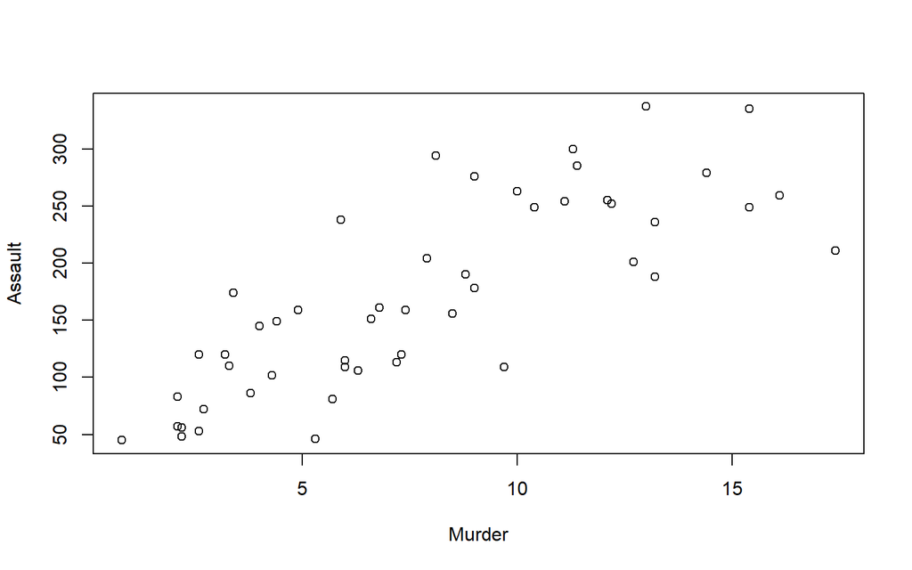

```r
attach(USArrests)
plot(Murder, Assault)
```

```r
par(las = 1) ## Horizontal axis units on y axis
```

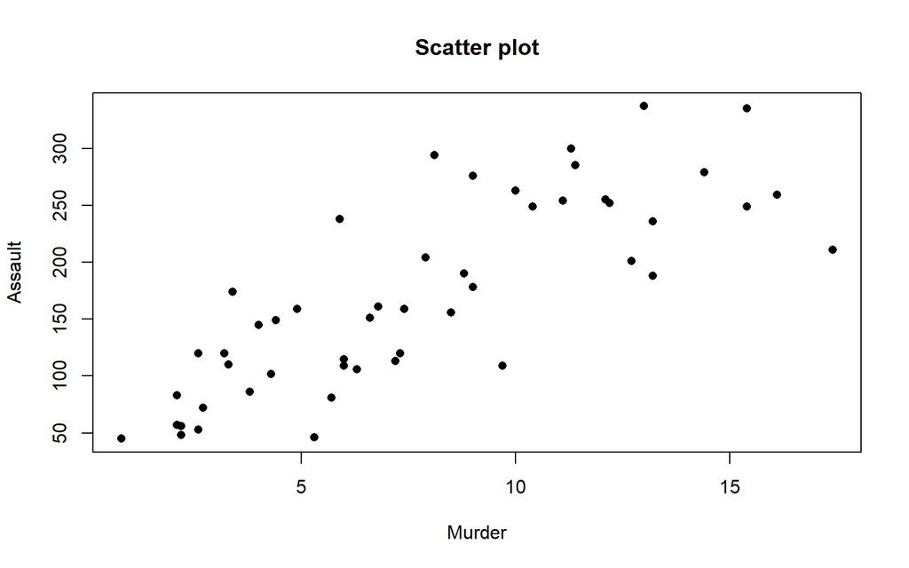

```r
plot(Murder, Assault, main = "Scatter plot", pch = 16)
```

There is a positive relationship between Murder and Assault. However, Is this plot enough?

We have more than two variables of interest. A set of pairwise scatterplots (sometimes called a draftsman plot) may be of use:

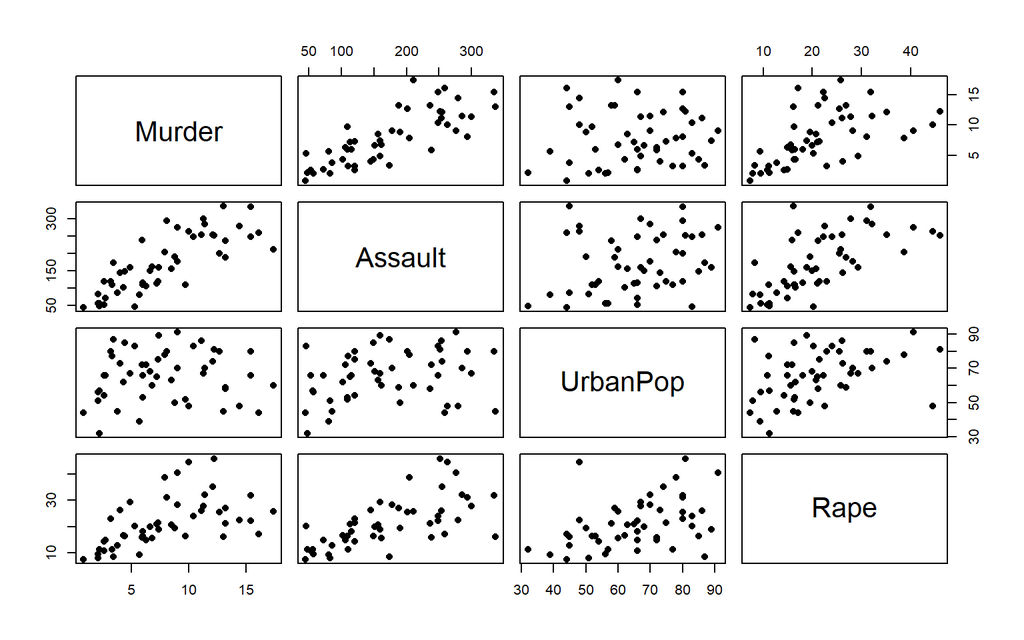

```r
pairs(USArrests, pch = 16)
```

There other useful functions available. For example what does splom do? (Look up >?splom).

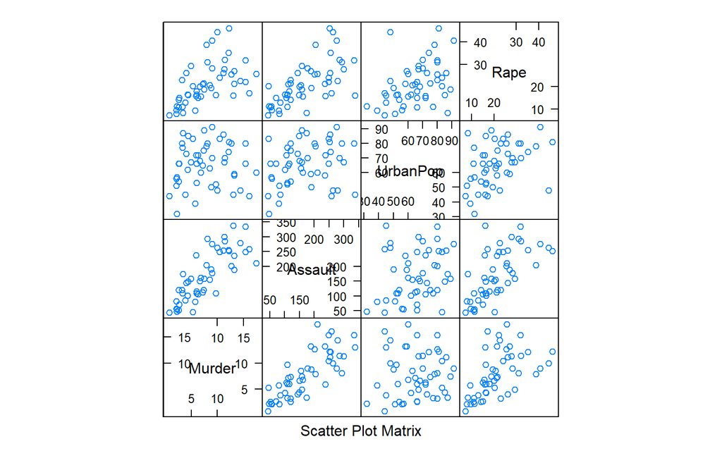

```r
library(lattice)
splom(~USArrests)
```

You can also visualize 3d scatter plot in R using `scatterplot3d`. While doing this,please consider three variables which are related to your interest.

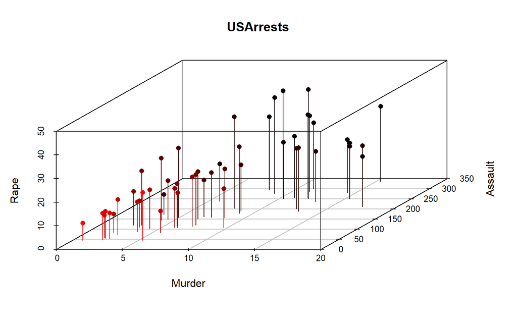

```r
library(scatterplot3d)
s3d <- scatterplot3d(USArrests[,-3], type="h", highlight.3d=TRUE,
                     angle=55, scale.y=0.7, pch=16, main = "USArrests")
```

**Correlation Plot**

You can also observe the multiple relationship in the data by drawing correlation plot.

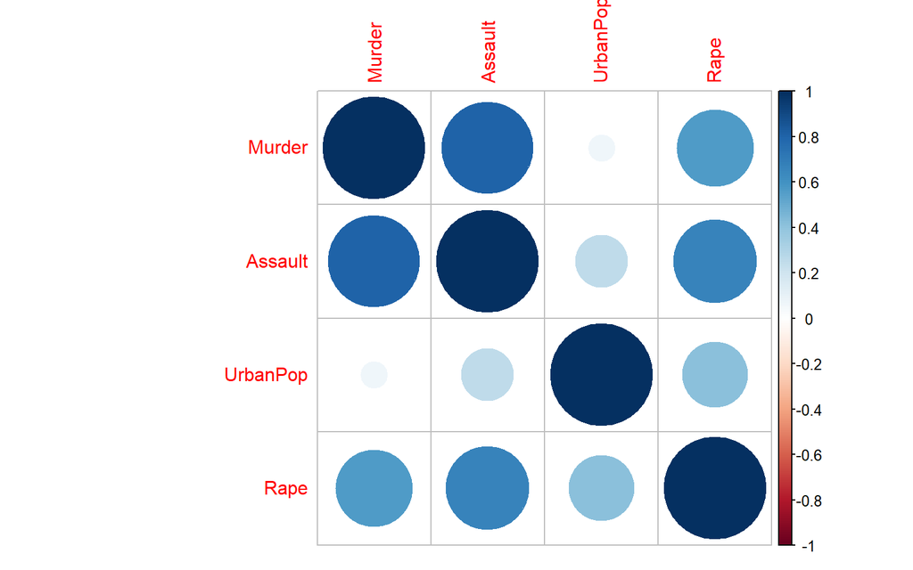

```r
library(corrplot)
corrplot(cor(USArrests), method="circle")
```

**The bivariate boxplot**

In many cases, it might be helpful to have a more formal and objective method for labelling observations as outliers, and such a method is provided by the bivariate boxplot, which is a two-dimensional analogue of the boxplot for univariate data proposed by Goldberg and Iglewicz (1992). This type of graphic may be useful in indicating the distributional properties of the data and in identifying possible outliers.

```
install.packages("MVA")
```

```r
library(MVA)
```

Suppose that we are interested in the relationship between urban population and rape.

```r
sub<-USArrests[,c("UrbanPop", "Rape")]
head(sub)
```

```
##            UrbanPop Rape
## Alabama          58 21.2
## Alaska           48 44.5
## Arizona          80 31.0
## Arkansas         50 19.5
## California       91 40.6
## Colorado         78 38.7
```

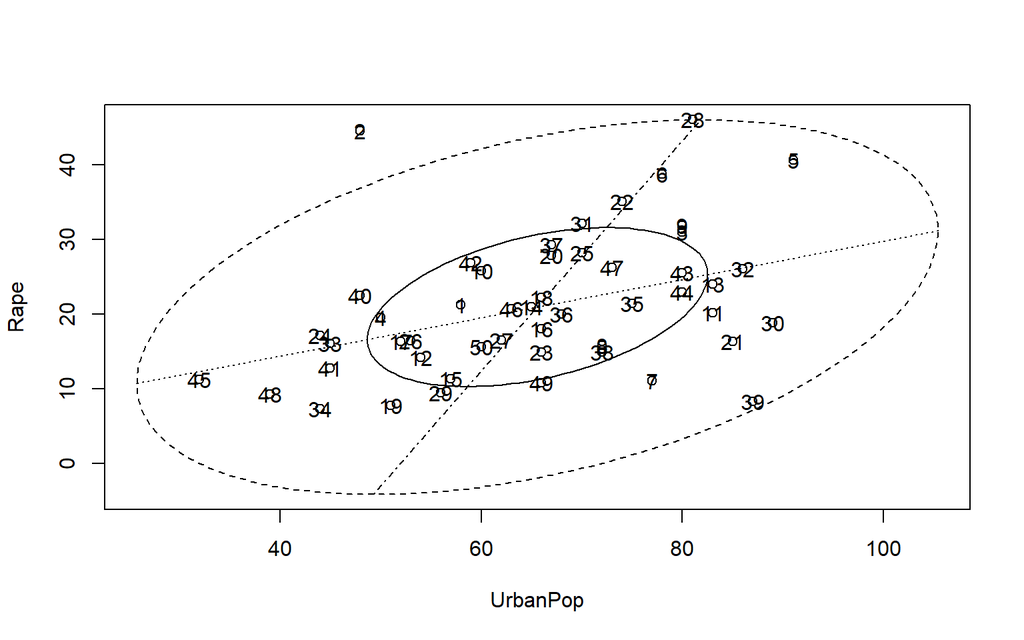

```r
bvbox(sub,xlab = "UrbanPop", ylab ="Rape")
text(sub$UrbanPop, sub$Rape)
```

If you would like to detect which observation is outlier you can use text function.

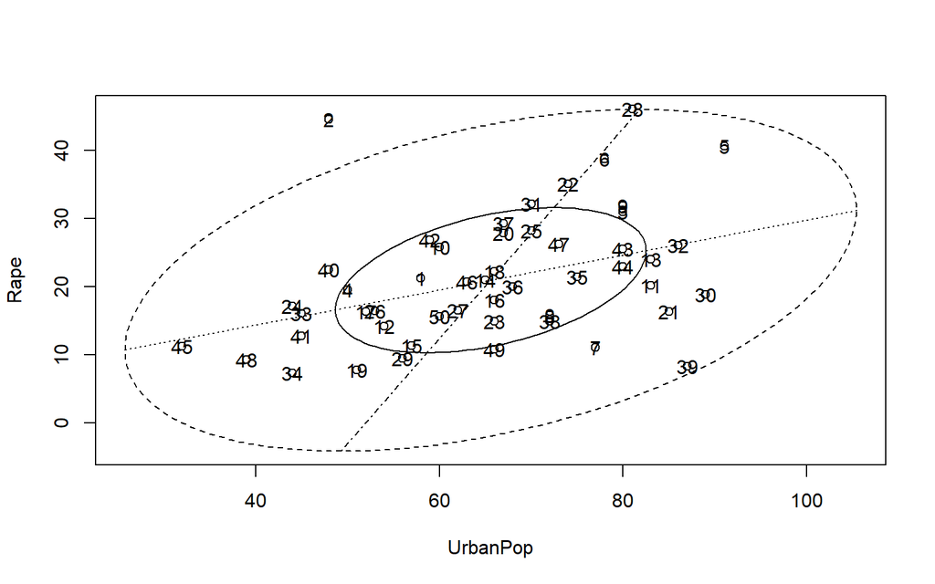

```r
bvbox(sub,xlab = "UrbanPop", ylab ="Rape")
text(sub$UrbanPop, sub$Rape)
```

It is seen that second city which is Alaska is the outlier in the data.

**The bubble and other glyph plots**

The basic scatterplot can only display two variables. But there have been a number of suggestions as to how extra variables may be included on a scatterplot. Perhaps the simplest is the so-called bubble plot, in which three variables are displayed; two are used to form the scatterplot itself, and then the values of the third variable are represented by circles with radii proportional to these values and centred on the appropriate point in the scatterplot.

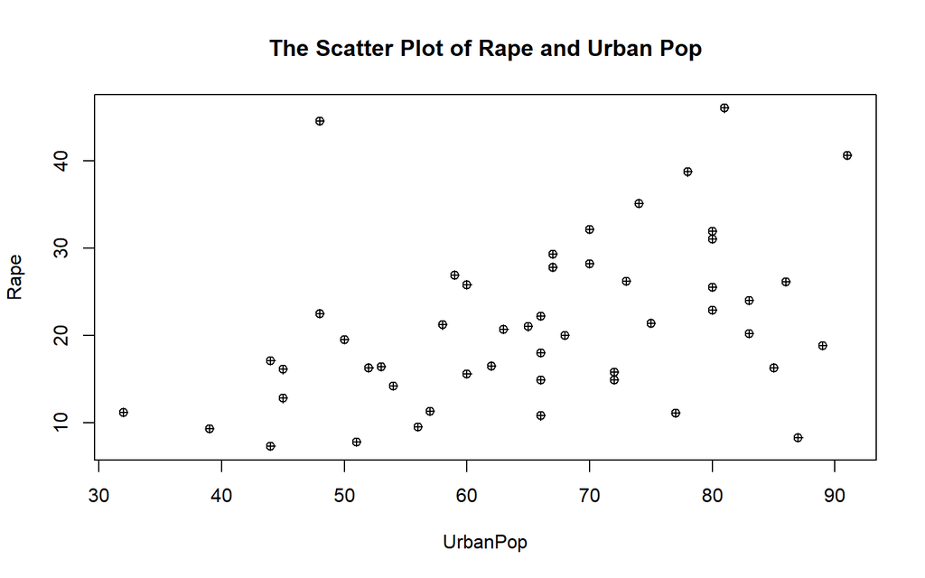

```r
#plot(y~x)
plot(Rape~UrbanPop, data = USArrests, pch = 10,main="The Scatter Plot of Rape and Urban Pop")
```

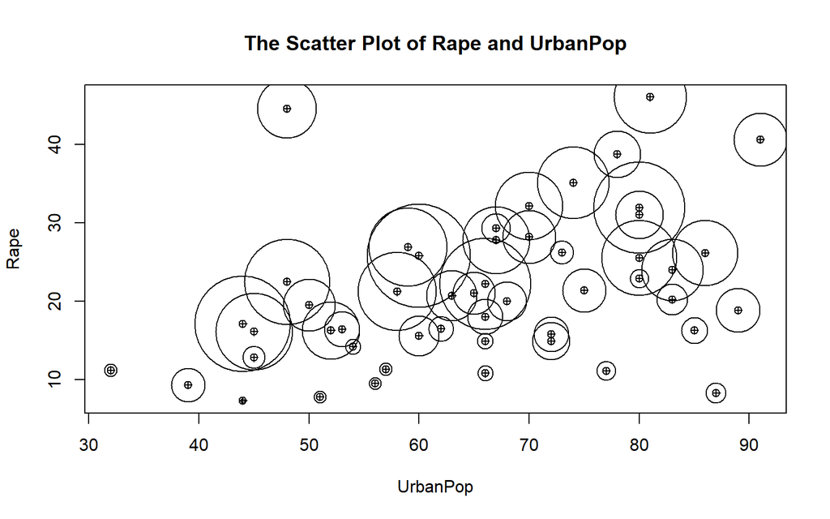

```r
plot(Rape~UrbanPop, data = USArrests, pch = 10,main="The Scatter Plot of Rape and UrbanPop")
with(USArrests,symbols(UrbanPop, Rape, circles = Murder,
inches = 0.5, add = TRUE))
```

The plot seems to suggest that crowded cities with high number of rape tend to suffer from the high number of murder.

**Chernoff’s Face and Star Plot**

Chernoff faces, invented by Herman Chernoff in 1973, display multivariate data in the shape of a human face. The individual parts, such as eyes, ears, mouth and nose represent values of the variables by their shape, size, placement and orientation.

```
install.packages("aplpack")
```

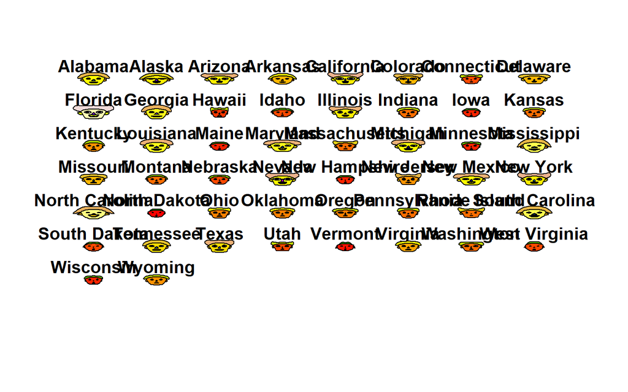

```
## effect of variables:
##  modified item       Var
##  "height of face   " "Murder"
##  "width of face    " "Assault"
##  "structure of face" "UrbanPop"
##  "height of mouth  " "Rape"
##  "width of mouth   " "Murder"
##  "smiling          " "Assault"
##  "height of eyes   " "UrbanPop"
##  "width of eyes    " "Rape"
##  "height of hair   " "Murder"
##  "width of hair   "  "Assault"
##  "style of hair   "  "UrbanPop"
##  "height of nose  "  "Rape"
##  "width of nose   "  "Murder"
##  "width of ear    "  "Assault"
##  "height of ear   "  "UrbanPop"
```

```r
library(aplpack)
faces(USArrests)
```

Star plot is the another version of Chernoff Faces which is drawn using same package.

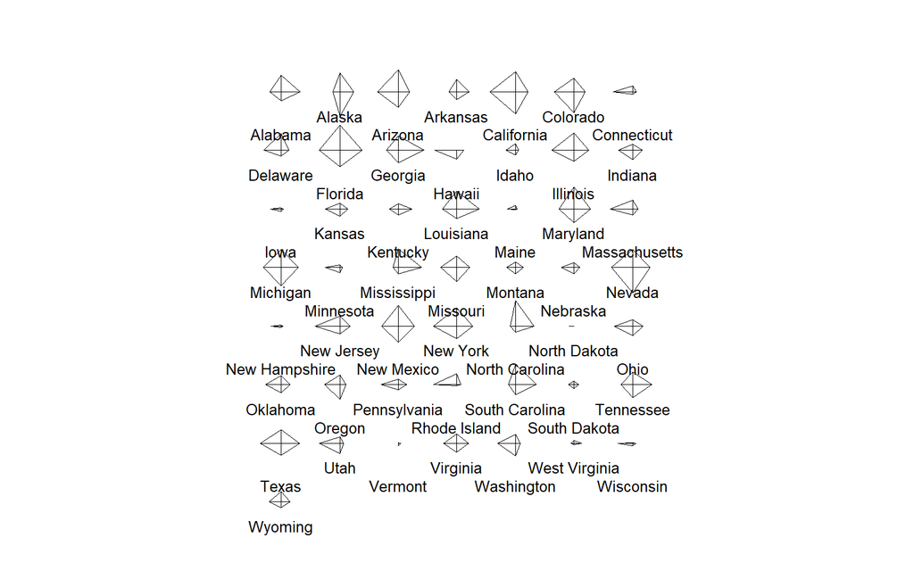

```r
stars(USArrests)
```

#### Estimating The Density

The way of estimating and visualizing the density of the variable is histogram with kernel density line. To do so,

```
install.packages("psych")
```

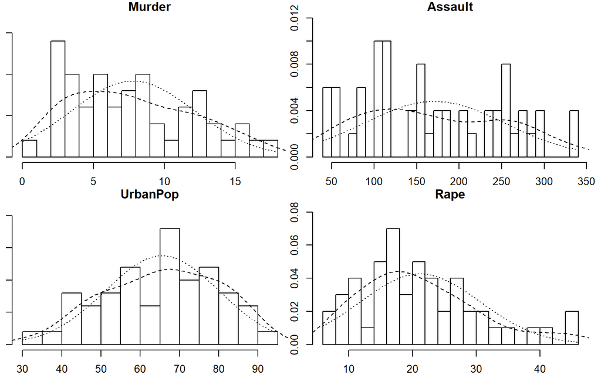

```r
library(psych)
multi.hist(USArrests)
```

As seen, rape has right skewed distribution. You can make similar interpretation for other variables.

#### Trellis graphics

Trellis graphics is an approach to examining high-dimensional structure in data by means of one-, two-, and three-dimensional graphs. The problem addressed is how observations of one or more variables depend on the observations of the other variables. The essential feature of this approach is the multiple conditioning that allows some type of plot to be displayed for different values of a given variable (or variables). The aim is to help in understanding both the structure of the data and how well proposed models describe the structure.

The trelli’s graphs is drawn using `xyplot` function.

For example,

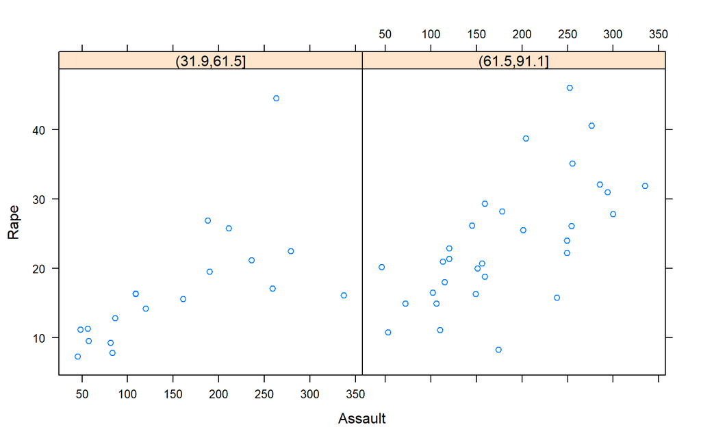

```r
xyplot(Rape ~ Assault | cut(UrbanPop,2), data = USArrests)
```

This is the scatter plot of assault and rape with respect to urban population. As seen, we observe increasing relationship in the both cases.

For more Trellis graph, you can [visit](https://www.stat.auckland.ac.nz/~ihaka/787/lectures-trellis.pdf).

## Assessing Normality in Multivariate Data

The ways of assesing normality in multivariate analsis were mentioned about at the beginning class, let’s try them and more in R.

There are many packages to check multivariate normality in R, among them I use `MVN` developed by Turkish Statisticians.

[figure not shown]

```r
library(MVN)
```

This package conducts all analysis via `mvn` funciton. This function includes all the arguments to assess multivariate normality through multivariate normality tests, multivariate plots, multivariate outlier detection, univariate normality tests and univariate plots.

```
mvn(data, subset = NULL, mvnTest = c("mardia", "hz", "royston", "dh",
"energy"), covariance = TRUE, tol = 1e-25, alpha = 0.5,
scale = FALSE, desc = TRUE, transform = "none", R = 1000,
univariateTest = c("SW", "CVM", "Lillie", "SF", "AD"),
univariatePlot = "none", multivariatePlot = "none",
multivariateOutlierMethod = "none", bc = FALSE, bcType = "rounded",
showOutliers = FALSE, showNewData = FALSE)
```

#### Chi-Square Plot

As univaraiate case, we will use both visual and numerical ways to check the multivariate normality.

The visual way of checking normality is drawing Chi-square QQ plot. To draw it, you can use the `multivariatePlot= "qq"` option in the `mvn.`

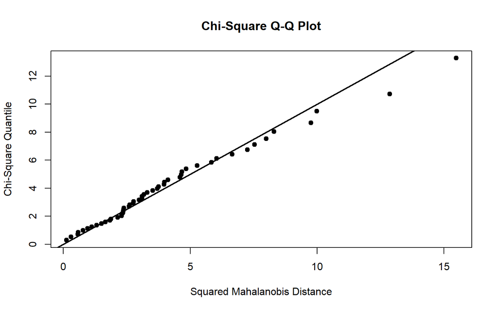

```
## $multivariateNormality
##              Test         Statistic            p value Result
## 1 Mardia Skewness  38.6236551434612 0.0074233268680534     NO
## 2 Mardia Kurtosis 0.962400363137224  0.335848531336779    YES
## 3             MVN              <NA>               <NA>     NO
##
## $univariateNormality
##           Test  Variable Statistic   p value Normality
## 1 Shapiro-Wilk  Murder      0.9570    0.0667    YES
## 2 Shapiro-Wilk  Assault     0.9518    0.0405    NO
## 3 Shapiro-Wilk UrbanPop     0.9771    0.4385    YES
## 4 Shapiro-Wilk   Rape       0.9467    0.0251    NO
##
## $Descriptives
##           n    Mean   Std.Dev Median  Min   Max    25th    75th       Skew
## Murder   50   7.788  4.355510   7.25  0.8  17.4   4.075  11.250  0.3706342
## Assault  50 170.760 83.337661 159.00 45.0 337.0 109.000 249.000  0.2205325
## UrbanPop 50  65.540 14.474763  66.00 32.0  91.0  54.500  77.750 -0.2126297
## Rape     50  21.232  9.366385  20.10  7.3  46.0  15.075  26.175  0.7537694
##             Kurtosis
## Murder   -0.94923036
## Assault  -1.14548686
## UrbanPop -0.87195504
## Rape      0.07510264
```

```r
mvn(USArrests,multivariatePlot= "qq")
```

It can be seen from Figure above that there are some deviations from the straight line and this indicates possible departures from a multivariate normal distribution.

#### Formal Tests

After the visual tool, we should conduct a formal test to check multivariate normality. In the literature, many numbers of multivariate normality test and this package gives an opportunity to use some of them.

For all tests, we test the following hypothesis.

$H_0$: The data follows normal distribution.

$H_1$: The data does not follow normal distribution.

- If you have a data where $n<20$, you can use Mardias MVN test by using `mvnTest = "mardia"` argument in `mvn` function.
- If you have a data where $n<5000$, you can use Roystons MVN test by using `mvnTest = "royston"` argument in `mvn` function.
- You can also use Henze-Zirklers MVN test which is not limited by sample size by using `mvnTest = "hz"` argument in `mvn` function.

In this example, I use Roystons MVN test since it depends on Shapiro-Wilk test.

```r
result <- mvn(data = USArrests, mvnTest = "royston")
result$multivariateNormality
```

```
##      Test        H    p value MVN
## 1 Royston 11.92728 0.01546474  NO
```

Since p value is less than $\alpha$, we reject $H_0$ and we can say that we don’t have enough evidence to prove that the data follow normal distribution.

#### Univariate Plots

Checking univariate plots and tests could be very useful to diagnose the reason for deviation from MVN. We can check this assumption through univariatePlot and univariateTest arguments from the `mvn` function. Set `univariatePlot` argument `"qq"` for Q-Q plots, `"histogram"` for histograms with normal curves, `"box"` for box-plots and `"scatter"` for scatterplot matrices.

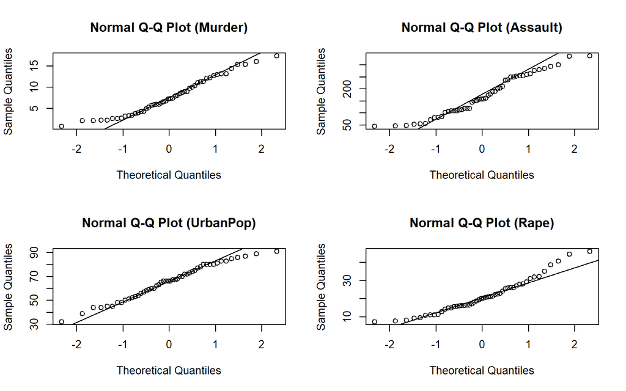

```r
# create univariate Q-Q plots
result <- mvn(data = USArrests, mvnTest = "royston", univariatePlot = "qqplot")
```

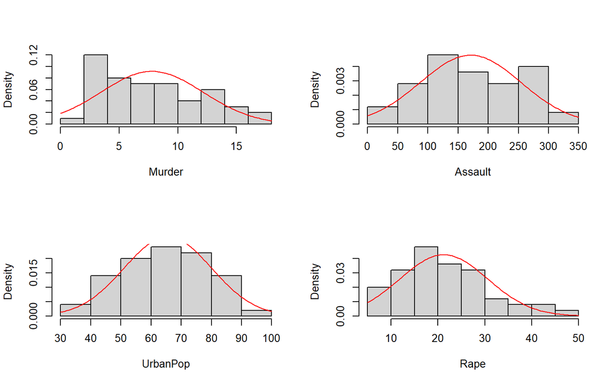

```r
# create univariate histograms
result <- mvn(data = USArrests, mvnTest = "royston", univariatePlot = "histogram")
```

```r
result$univariateNormality #univariate normality result.
```

```
##           Test  Variable Statistic   p value Normality
## 1 Shapiro-Wilk  Murder      0.9570    0.0667    YES
## 2 Shapiro-Wilk  Assault     0.9518    0.0405    NO
## 3 Shapiro-Wilk UrbanPop     0.9771    0.4385    YES
## 4 Shapiro-Wilk   Rape       0.9467    0.0251    NO
```

As you see, Rape and Assult are the variables which violates the multivaraite normality.

#### Outlier Detection

Multivariate outliers are the common reason for violating MVN assumption. In other words, MVN assumption requires the absence of multivariate outliers. Thus, it is crucial to check whether the data have multivariate outliers, before starting to multivariate analysis. The MVN includes two multivariate outlier detection methods which are based on robust Mahalanobis distances and adjusted Mahalanobis distance.

```r
# Mahalanobis distance
result <- mvn(data = USArrests, mvnTest = "royston", multivariateOutlierMethod = "quan")
```

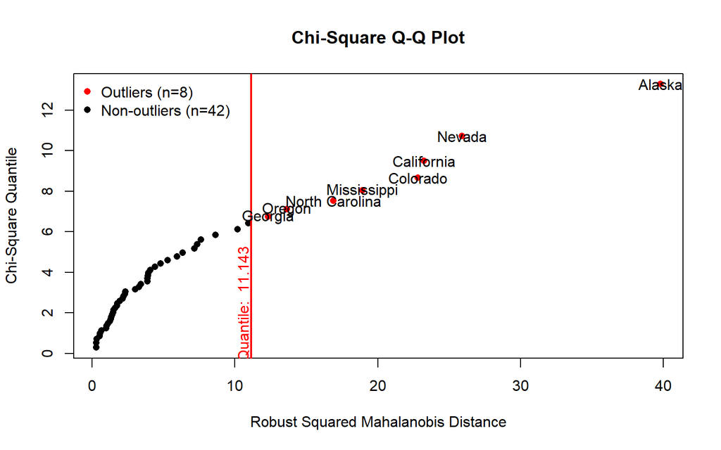

As seen that, we have 8 outlier observations proved by Mahalanobis Distance in this dataset.

```r
# Adjusted Mahalanobis distance
result <- mvn(data = USArrests, mvnTest = "royston", multivariateOutlierMethod = "adj")
```

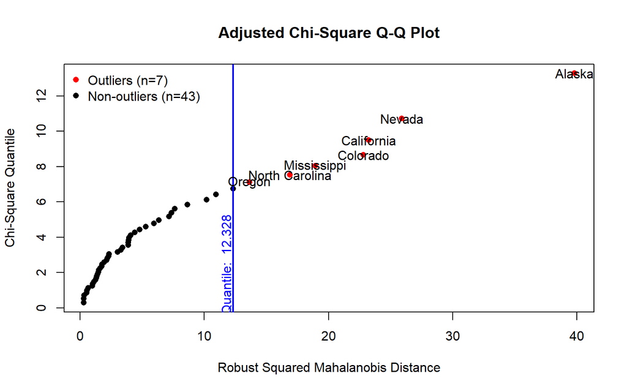

As seen that, we have 7 outlier observations proved by Adjusted Mahalanobis Distance in this dataset.